# Predicting Stroke

Tutorial by Malick Keita

# Introduction

In this tutorial, I will walk you through the data science pipeline in which we will discuss data collection, data processing, exploratory analysis & data visualization, analysis hypothesis/ machine learning and decision.

# Why is it so important to predict stroke?

A stroke is a cardiovascular disease that affects brains' cells when its tissues lack oxygen. According to the CDC, over 795,000 people in the United States have stroke every year. In additon, someone dies of stroke every 40 seconds in the United States. Since this situation is critical, it is necessary to have an idea about the proportion of the population who is mostly affected by this disease and predict who might get it based on the current data. In this case, I define proportion as gender, high BMI, smokers, and people with underlining conditions.

https://www.cdc.gov/stroke/facts.htm

# Data Collection

We will be using a dataset "Stroke Prediction dataset" that we downloaded as a csv(comma separated values) file from the website https://www.kaggle.com/fedesoriano/stroke-prediction-dataset. This dataset has 12 essential features(variables) with 5110 observations representing information collected from several patients.

Here is the detail of features representing each column and its expected value.

1) id: unique identifier

2) gender: "Male", "Female" or "Other"

3) age: age of the patient

4) hypertension: 0 if the patient doesn't have hypertension, 1 if the patient has hypertension

5) heart_disease: 0 if the patient doesn't have any heart diseases, 1 if the patient has a heart disease

6) ever_married: "No" or "Yes"

7) work_type: "children", "Govt_jov", "Never_worked", "Private" or "Self-employed"

8) Residence_type: "Rural" or "Urban"

9) avg_glucose_level: average glucose level in blood

10) bmi: body mass index

11) smoking_status: "formerly smoked", "never smoked", "smokes" or "Unknown"*

12) stroke: 1 if the patient had a stroke or 0 if not

*Note: "Unknown" in smoking_status means that the information is unavailable for this patient

This is an interesting dataset since it contains important information that will help us with our prediction.

Since we now have the dataset available, we will use the library called pandas which will enable us to store, clean and analyze it.

```python
# Import essential libraries
import pandas as pd
import numpy as np
import statsmodels.api as sm
import matplotlib.pyplot as plt
from pandas.plotting import scatter_matrix
import numpy as np
import seaborn as sns
# Ignore SettingWithCopyWarning warning
import warnings
from pandas.core.common import SettingWithCopyWarning
from sklearn.linear_model import LinearRegression
```

We read the data into a dataframe to store and manage the dataset using pandas then we print few rows to make sure it is well-stored

```python
# Store data into pandas dataframe and show few observations from the dataset
data = pd.read_csv('healthcare-dataset-stroke-data.csv', sep=',')
data.head()
```

|  | id | gender | age | hypertension | heart_disease | ever_married | work_type | Residence_type | avg_glucose_level | bmi | smoking_status | stroke |
| --- | --- | --- | --- | --- | --- | --- | --- | --- | --- | --- | --- | --- |
| 0 | 9046 | Male | 67.0 | 0 | 1 | Yes | Private | Urban | 228.69 | 36.6 | formerly smoked | 1 |
| 1 | 51676 | Female | 61.0 | 0 | 0 | Yes | Self-employed | Rural | 202.21 | NaN | never smoked | 1 |
| 2 | 31112 | Male | 80.0 | 0 | 1 | Yes | Private | Rural | 105.92 | 32.5 | never smoked | 1 |
| 3 | 60182 | Female | 49.0 | 0 | 0 | Yes | Private | Urban | 171.23 | 34.4 | smokes | 1 |
| 4 | 1665 | Female | 79.0 | 1 | 0 | Yes | Self-employed | Rural | 174.12 | 24.0 | never smoked | 1 |

Perform a quick statistical analysis on the data to have an overview of the general trend.

```python
data.describe()
```

|  | id | age | hypertension | heart_disease | avg_glucose_level | bmi | stroke |
| --- | --- | --- | --- | --- | --- | --- | --- |
| count | 5110.000000 | 5110.000000 | 5110.000000 | 5110.000000 | 5110.000000 | 4909.000000 | 5110.000000 |
| mean | 36517.829354 | 43.226614 | 0.097456 | 0.054012 | 106.147677 | 28.893237 | 0.048728 |
| std | 21161.721625 | 22.612647 | 0.296607 | 0.226063 | 45.283560 | 7.854067 | 0.215320 |
| min | 67.000000 | 0.080000 | 0.000000 | 0.000000 | 55.120000 | 10.300000 | 0.000000 |
| 25% | 17741.250000 | 25.000000 | 0.000000 | 0.000000 | 77.245000 | 23.500000 | 0.000000 |
| 50% | 36932.000000 | 45.000000 | 0.000000 | 0.000000 | 91.885000 | 28.100000 | 0.000000 |
| 75% | 54682.000000 | 61.000000 | 0.000000 | 0.000000 | 114.090000 | 33.100000 | 0.000000 |
| max | 72940.000000 | 82.000000 | 1.000000 | 1.000000 | 271.740000 | 97.600000 | 1.000000 |

# Data Processing

In this step, we will start cleaning the data by converting some data into correct datatypes, dealing with missing data and creating new columns from existing ones for a better exploration.

```python
# Convert age datatype to integer
data = data.astype({"age":'int'})
```

```python
# Create a column age_range that break down the column age into 5 classes of age
data['age_range'] = pd.cut(data['age'], bins=[0, 20, 40, 60, 80, 100])
```

```python
# Create a dataframe from current data by excluding observations with missing information
no_missing_data = data.dropna()
```

```python
no_missing_data.head()
```

|  | id | gender | age | hypertension | heart_disease | ever_married | work_type | Residence_type | avg_glucose_level | bmi | smoking_status | stroke | age_range |
| --- | --- | --- | --- | --- | --- | --- | --- | --- | --- | --- | --- | --- | --- |
| 0 | 9046 | Male | 67 | 0 | 1 | Yes | Private | Urban | 228.69 | 36.6 | formerly smoked | 1 | (60, 80] |
| 2 | 31112 | Male | 80 | 0 | 1 | Yes | Private | Rural | 105.92 | 32.5 | never smoked | 1 | (60, 80] |
| 3 | 60182 | Female | 49 | 0 | 0 | Yes | Private | Urban | 171.23 | 34.4 | smokes | 1 | (40, 60] |
| 4 | 1665 | Female | 79 | 1 | 0 | Yes | Self-employed | Rural | 174.12 | 24.0 | never smoked | 1 | (60, 80] |
| 5 | 56669 | Male | 81 | 0 | 0 | Yes | Private | Urban | 186.21 | 29.0 | formerly smoked | 1 | (80, 100] |

```python
no_missing_data
```

|  | id | gender | age | hypertension | heart_disease | ever_married | work_type | Residence_type | avg_glucose_level | bmi | smoking_status | stroke | age_range |
| --- | --- | --- | --- | --- | --- | --- | --- | --- | --- | --- | --- | --- | --- |
| 0 | 9046 | Male | 67 | 0 | 1 | Yes | Private | Urban | 228.69 | 36.6 | formerly smoked | 1 | (60, 80] |
| 2 | 31112 | Male | 80 | 0 | 1 | Yes | Private | Rural | 105.92 | 32.5 | never smoked | 1 | (60, 80] |
| 3 | 60182 | Female | 49 | 0 | 0 | Yes | Private | Urban | 171.23 | 34.4 | smokes | 1 | (40, 60] |
| 4 | 1665 | Female | 79 | 1 | 0 | Yes | Self-employed | Rural | 174.12 | 24.0 | never smoked | 1 | (60, 80] |
| 5 | 56669 | Male | 81 | 0 | 0 | Yes | Private | Urban | 186.21 | 29.0 | formerly smoked | 1 | (80, 100] |
| ... | ... | ... | ... | ... | ... | ... | ... | ... | ... | ... | ... | ... | ... |
| 5104 | 14180 | Female | 13 | 0 | 0 | No | children | Rural | 103.08 | 18.6 | Unknown | 0 | (0, 20] |
| 5106 | 44873 | Female | 81 | 0 | 0 | Yes | Self-employed | Urban | 125.20 | 40.0 | never smoked | 0 | (80, 100] |
| 5107 | 19723 | Female | 35 | 0 | 0 | Yes | Self-employed | Rural | 82.99 | 30.6 | never smoked | 0 | (20, 40] |
| 5108 | 37544 | Male | 51 | 0 | 0 | Yes | Private | Rural | 166.29 | 25.6 | formerly smoked | 0 | (40, 60] |
| 5109 | 44679 | Female | 44 | 0 | 0 | Yes | Govt_job | Urban | 85.28 | 26.2 | Unknown | 0 | (40, 60] |

4867 rows × 13 columns

Now we will be using the dataset without missing data to continue our processing

# Exploratory Data Analysis

Let's calculate the percentage of patient who had stroke based on gender. To achieve this, we will create two dataframes by grouping male and female information separately

```python
# Dataframe for male patients
male_patient = no_missing_data.query('gender == "Male"')
# Dataframe for male patients who had stroke
male_patient_stroke = no_missing_data.query('gender == "Male" & stroke == 1')
```

```python
# Percentage of male patients who had a stroke
male_stroke_percentage = ((len(male_patient_stroke.index) * 1.0) / len(male_patient.index)) * 100
```

```python
print("The percentage of male patients who had a stroke is ", male_stroke_percentage, "%")
```

```
The percentage of male patients who had a stroke is  4.485887096774194 %
```

```python
# Dataframe for female patients
female_patient = no_missing_data.query('gender == "Female"')
# Dataframe for female patients who had stroke
female_patient_stroke = no_missing_data.query('gender == "Female" & stroke == 1')
```

```python
# Percentage of male patients who had a stroke
# we get the number of rows in female_patient_stroke and divide it by the total number of female patients
female_stroke_percentage = ((len(female_patient_stroke.index) * 1.0) / len(female_patient.index)) * 100
```

```python
print("The percentage of female patients who had a stroke is ", female_stroke_percentage, "%")
```

```
The percentage of female patients who had a stroke is  4.163775156141568 %
```

This shows that roughly 4.49 % of male had a stroke, whereas 4.16 % of female had a stroke.

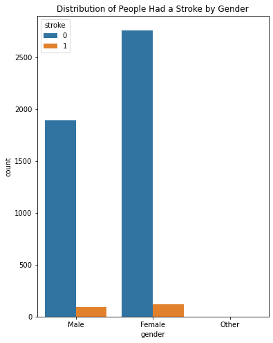

```python
# Let's show roughly the number of patients who had a stroke
plt.subplots(figsize=(6, 8))
sns.countplot(x="gender", data=no_missing_data, hue ='stroke')
plt.title('Distribution of People Had a Stroke by Gender')
plt.show()
```

Now that we know the percentage of male and female patients who had a stroke, we will use a heatmap and a matrix correlation to determine relationship between variables of the dataset.

```python
# Since we do not need the ID of the patient for our analysis, we can drop the ID column
# Execute the line below to ignore warning
warnings.simplefilter(action="ignore", category=SettingWithCopyWarning)
no_missing_data.drop('id', inplace = True, axis = 1)
```

```python
# we create a dataframe to store all patients who had a stroke
patient_with_stroke = no_missing_data.query('stroke == 1')
```

```python
patient_with_stroke.head()
```

|  | gender | age | hypertension | heart_disease | ever_married | work_type | Residence_type | avg_glucose_level | bmi | smoking_status | stroke | age_range |
| --- | --- | --- | --- | --- | --- | --- | --- | --- | --- | --- | --- | --- |
| 0 | Male | 67 | 0 | 1 | Yes | Private | Urban | 228.69 | 36.6 | formerly smoked | 1 | (60, 80] |
| 2 | Male | 80 | 0 | 1 | Yes | Private | Rural | 105.92 | 32.5 | never smoked | 1 | (60, 80] |
| 3 | Female | 49 | 0 | 0 | Yes | Private | Urban | 171.23 | 34.4 | smokes | 1 | (40, 60] |
| 4 | Female | 79 | 1 | 0 | Yes | Self-employed | Rural | 174.12 | 24.0 | never smoked | 1 | (60, 80] |
| 5 | Male | 81 | 0 | 0 | Yes | Private | Urban | 186.21 | 29.0 | formerly smoked | 1 | (80, 100] |

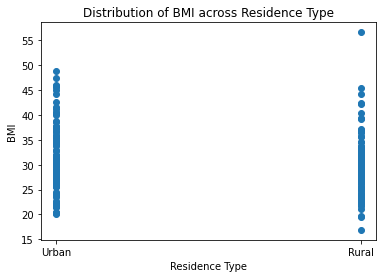

```python
# to produce plots that illustrate the distribution of
# bmi vs Residence_type across age_range for patients with stroke
plt.scatter(patient_with_stroke['Residence_type'], patient_with_stroke['bmi'])
plt.xlabel('Residence Type')
plt.ylabel('BMI')
plt.title('Distribution of BMI across Residence Type')
plt.show()
```

Based on the above plot, it is hard to determine a trend because people who live in rural area and had a stroke seem to have the lowest and highest bmi.

As we move along with the analysis, I have decided to use a heatmap and a matrix of correlations to help us relationships between dependent and independent variables. Here are the list of some variables by category

Independent variables: age, gender, id

Dependent variables: stroke, avg_glucose_level, bmi

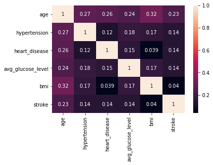

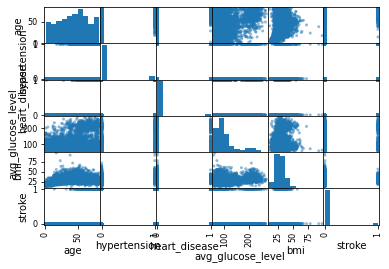

```python
# Plot heatmap and matrix of correlations
corr = no_missing_data.corr()
sns.heatmap(corr, annot = True)
plt.show()
scatter_matrix(no_missing_data)
plt.show()
```

An assumption that can be made about age and stroke is that most patients who had a stroke are old.

Let's graph a scatter plot to visualize and confirm these hypotheses about the correlation.

### AGE VS BMI

As it is mentioned earlier, we will plot the distribution of bmi accross age

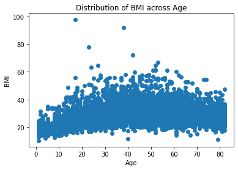

```python
# to produce plots that illustrate the distribution of
# bmi vs age
plt.scatter(no_missing_data['age'], no_missing_data['bmi'])
plt.xlabel('Age')
plt.ylabel('BMI')
plt.title('Distribution of BMI across Age')
plt.show()
```

Here we reproduce the above graph by classifying by age_range

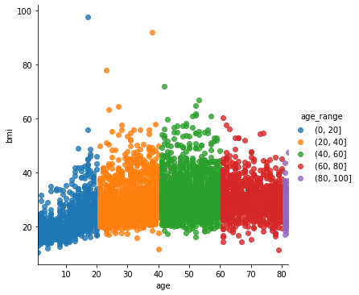

```python
# to produce plots that illustrate the distribution of
# bmi vs age by age_range
g = sns.lmplot(
    data=no_missing_data,
    x="age", y="bmi", hue="age_range",
    height=5
)
```

The above plots confirmed a positive correlation, but it doesn't seem to be a strong relationship.

### AGE VS STROKE

As mentioned in the dataframe, in stroke column, 1 represents people who had a stroke and 0 represents those who didn't.

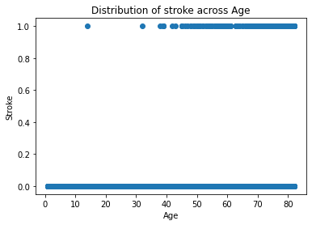

```python
# to produce plots that illustrate the distribution of
# stroke vs age
plt.scatter(no_missing_data['age'], no_missing_data['stroke'])
plt.xlabel('Age')
plt.ylabel('Stroke')
plt.title('Distribution of stroke across Age')
plt.show()
```

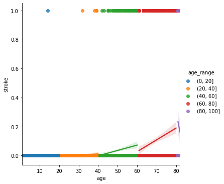

```python
# to produce plots that illustrate the distribution of
# stroke vs age by age_range
g = sns.lmplot(
    data=no_missing_data,
    x="age", y="stroke", hue="age_range",
    height=5
)
```

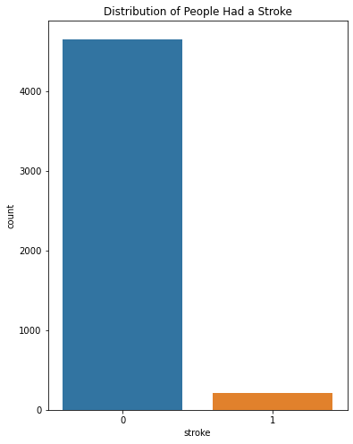

```python
# Let's show roughly the number of patients who had a stroke
plt.subplots(figsize=(6, 8))
sns.countplot(x="stroke", data=no_missing_data)
plt.title('Distribution of People Had a Stroke')
plt.show()
```

Now, let's conduct a regression analysis to create models that will help us make predictions.

### Model for Age vs Stroke

```python
# We create linear regression model to predict stroke based on age
# Independent Variable
X = no_missing_data['age']
# Dependent Variable
y = no_missing_data['stroke']
model = sm.OLS(y,X).fit()
predictions = model.predict(X)
model.summary()
```

OLS Regression Results

| Dep. Variable: | stroke | R-squared (uncentered): | 0.083 |
| --- | --- | --- | --- |
| Model: | OLS | Adj. R-squared (uncentered): | 0.083 |
| Method: | Least Squares | F-statistic: | 441.6 |
| Date: | Mon, 17 May 2021 | Prob (F-statistic): | 6.36e-94 |
| Time: | 01:52:13 | Log-Likelihood: | 965.84 |
| No. Observations: | 4867 | AIC: | -1930. |
| Df Residuals: | 4866 | BIC: | -1923. |
| Df Model: | 1 |  |  |
| Covariance Type: | nonrobust |  |  |

|  | coef | std err | t | P>\|t\| | [0.025 | 0.975] |
| --- | --- | --- | --- | --- | --- | --- |
| age | 0.0012 | 5.85e-05 | 21.015 | 0.000 | 0.001 | 0.001 |

| Omnibus: | 4220.251 | Durbin-Watson: | 0.040 |
| --- | --- | --- | --- |
| Prob(Omnibus): | 0.000 | Jarque-Bera (JB): | 78410.540 |
| Skew: | 4.380 | Prob(JB): | 0.00 |
| Kurtosis: | 20.605 | Cond. No. | 1.00 |

Notes:  
[1] R² is computed without centering (uncentered) since the model does not contain a constant.  
[2] Standard Errors assume that the covariance matrix of the errors is correctly specified.

The graph below shows a little increase in the chance of having a stroke over time.

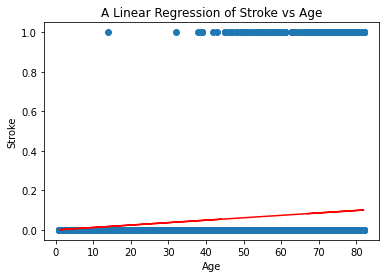

```python
# Plot with with fitted model
fig, ax = plt.subplots()

ax.scatter(no_missing_data.age.values.reshape(-1,1), no_missing_data.stroke.values)
ax.set_xlabel("Age")
ax.set_ylabel("Stroke")
ax.set_title("A Linear Regression of Stroke vs Age")

ax.plot(no_missing_data.age.values.reshape(-1,1), model.predict(no_missing_data.age.values.reshape(-1,1)), color='red')
```

### Analysis of the regression

The analysis of R-squared done above is to see the variability of the dependent variable and the independent variable. Additionally, the given p-value is less than 0.05 which represents 95% confidence level. In this case, as we reject the null hypothesis, we can say that there is a relationship between variables.

#### Summary Analysis of age vs stroke

The R-squared value tells us that 8.3% of the observed variation for stroke can be explained by age. The P>|t| indicates that there is a statistically a relationship between age and stroke even if it is not strong.

### Model for Age vs bmi

```python
# We create linear regression model to predict stroke based on age
# Independent Variable
X = no_missing_data['age']
# Dependent Variable
y = no_missing_data['bmi']
model = sm.OLS(y,X).fit()
predictions = model.predict(X)
model.summary()
```

OLS Regression Results

| Dep. Variable: | bmi | R-squared (uncentered): | 0.803 |
| --- | --- | --- | --- |
| Model: | OLS | Adj. R-squared (uncentered): | 0.803 |
| Method: | Least Squares | F-statistic: | 1.982e+04 |
| Date: | Mon, 17 May 2021 | Prob (F-statistic): | 0.00 |
| Time: | 01:52:30 | Log-Likelihood: | -19511. |
| No. Observations: | 4867 | AIC: | 3.902e+04 |
| Df Residuals: | 4866 | BIC: | 3.903e+04 |
| Df Model: | 1 |  |  |
| Covariance Type: | nonrobust |  |  |

|  | coef | std err | t | P>\|t\| | [0.025 | 0.975] |
| --- | --- | --- | --- | --- | --- | --- |
| age | 0.5530 | 0.004 | 140.791 | 0.000 | 0.545 | 0.561 |

| Omnibus: | 11.590 | Durbin-Watson: | 1.652 |
| --- | --- | --- | --- |
| Prob(Omnibus): | 0.003 | Jarque-Bera (JB): | 14.086 |
| Skew: | -0.023 | Prob(JB): | 0.000874 |
| Kurtosis: | 3.259 | Cond. No. | 1.00 |

Notes:  
[1] R² is computed without centering (uncentered) since the model does not contain a constant.  
[2] Standard Errors assume that the covariance matrix of the errors is correctly specified.

#### Summary Analysis of age vs bmi

The R-squared value tells us that 80.3% of the observed variation for bmi can be explained by age. The P>|t| indicates that there is statistically a significant relationship between age and bmi.

### Interaction terms with dummy variables

In this step, we will change the values of columns gender, residence_type, ever_married to boolean(0 or 1) for a better analysis. This is basically representing categorical variables as numeric values.

```python
# Change columns values to boolean type(0 or 1)
no_missing_data['gender']= no_missing_data['gender'].apply(lambda x : 1 if x =='Male' else 0)
no_missing_data["Residence_type"] = no_missing_data["Residence_type"].apply(lambda x: 1 if x=="Urban" else 0)
no_missing_data["ever_married"] = no_missing_data["ever_married"].apply(lambda x: 1 if x=="Yes" else 0)
```

```python
# Drop missing data from smoking status
no_missing_data = no_missing_data[no_missing_data['smoking_status']!='Unknown']
```

```python
#Used interaction terms and dummy variables for smoking_status, work_type

data_dummies = no_missing_data[['smoking_status','work_type']]
data_dummies = pd.get_dummies(data_dummies)
no_missing_data.drop(columns=['smoking_status','work_type', 'age_range'],inplace=True)
```

```python
no_missing_data.head()
```

|  | gender | age | hypertension | heart_disease | ever_married | Residence_type | avg_glucose_level | bmi | stroke |
| --- | --- | --- | --- | --- | --- | --- | --- | --- | --- |
| 0 | 1 | 67 | 0 | 1 | 1 | 1 | 228.69 | 36.6 | 1 |
| 2 | 1 | 80 | 0 | 1 | 1 | 0 | 105.92 | 32.5 | 1 |
| 3 | 0 | 49 | 0 | 0 | 1 | 1 | 171.23 | 34.4 | 1 |
| 4 | 0 | 79 | 1 | 0 | 1 | 0 | 174.12 | 24.0 | 1 |
| 5 | 1 | 81 | 0 | 0 | 1 | 1 | 186.21 | 29.0 | 1 |

Before we train our data, we will need to do a little bit of processing by merging our dataset with the dummy data that we created above.

```python
# Create a model and merge data_dummies and
# no_missing_data
y = no_missing_data['stroke']
no_missing_data.drop(columns=['stroke'],inplace=True)
x = no_missing_data.merge(data_dummies,left_index = True, right_index = True, how ='left')
```

Now we can start splitting our data and train our model by using the library sklearn.

### Data splitting

```python
# Split dataset into train and test data
from sklearn.model_selection import train_test_split
X_train, X_test, Y_train, Y_test = train_test_split(x, y, test_size = 0.20, random_state = 0)
```

```python
# Print shape of individual dataset
print(X_train.shape)
print(X_test.shape)
print(Y_train.shape)
print(Y_test.shape)
```

```
(2740, 16)
(686, 16)
(2740,)
(686,)
```

Here we will standardize our data to make sure it is normally distributed. Doing so will help us apply machine learning techniques to train and make predictions with our dataset.

```python
# Normalize dataset
from sklearn.preprocessing import StandardScaler

sc = StandardScaler()

X_train = sc.fit_transform(X_train)
X_test = sc.transform(X_test)
```

```python
X_train
```

```
array([[-0.8072158 ,  0.70299503, -0.36620481, ..., -1.33164536,
         2.10119484, -0.14312292],
       [-0.8072158 ,  1.43971476, -0.36620481, ...,  0.75095069,
        -0.47591969, -0.14312292],
       [-0.8072158 , -0.71782161, -0.36620481, ...,  0.75095069,
        -0.47591969, -0.14312292],
       ...,
       [-0.8072158 ,  1.65020611, -0.36620481, ..., -1.33164536,
         2.10119484, -0.14312292],
       [-0.8072158 ,  0.07152097, -0.36620481, ...,  0.75095069,
        -0.47591969, -0.14312292],
       [ 1.2388261 ,  0.33463516, -0.36620481, ..., -1.33164536,
        -0.47591969, -0.14312292]])
```

Now that the training data is normalized, we can use the regression algorithm to make predictions.

```python
lr = LinearRegression()
lr.fit(X_train, Y_train)
```

```
LinearRegression()
```

```python
lr.predict(X_test)
```

[output not shown]

[output cut: 117 more lines]

[output not shown]

```python
# We extract and print the slope and intercept
# from the equation
m = lr.coef_[0]
b = lr.intercept_
print("slope =", m, "intercept =", b)
```

```
slope = -0.0005744028676215552 intercept = 0.05401459854014599
```

### Machine Learning

Now we will use a decisionTreeClassifier as our machine learning technique to make predictions about stroke.

Machine learning is the study of computer algorithms that improve automatically through experience and by the use of data. This means that the algorithm learns from the given data and uses that knowledge to predict the future.

```python
from sklearn.tree import DecisionTreeClassifier

# we create a decision tree model to classify our train data
dt_model = DecisionTreeClassifier(criterion ='entropy', max_depth = 8)
dt_model.fit(X_train, Y_train)
```

```
DecisionTreeClassifier(criterion='entropy', max_depth=8)
```

```python
y_pred = dt_model.predict(X_test)
y_pred
```

[output not shown]

[output cut: 17 more lines]

```python
# Determine accuracy score of the model
score = dt_model.score(X_test, Y_test)
print("The score given by our model is", score)
```

```
The score given by our model is 0.9402332361516035
```

## Conclusion

As I mentioned at the beginning of this tutorial, stroke is a serious disease that is among the top causes of death. However, it is challenging to have accurate model to predict stroke. It can be caused by several issues, such as high bmi(obesity), heart disease or age. In addition, our model predicts that there is a chance to have a stroke as people get older. On the other hand, I have learned about several aspects of stroke. The patients' data contains important features, such as bmi, age, hypertension, and heart_disease. Through exploratory data analysis I found several features that correlated with age.

Another important thing that I noticed is the correlation between age and bmi. Even if we are more focusing on stroke, high bmi could be a source of a lot of diseases. However, I think that further investigations should be done to have answers to major questions related to stroke.

## Related Links

To further your knowledge about data science or perhaps continuing this analysis, these are important information to get started.

Statistical Analysis

https://seaborn.pydata.org/generated/seaborn.heatmap.html

https://seaborn.pydata.org/examples/many_pairwise_correlations.html

Machine Learning

Linear Regression

https://machinelearningmastery.com/linear-regression-for-machine-learning/

Decision Trees

https://www.kdnuggets.com/2020/01/decision-tree-algorithm-explained.html

Resources

https://medium.com/geekculture/stroke-prediction-d26c15f9d1

https://pubmed.ncbi.nlm.nih.gov/24976094/

https://www.kaggle.com/fedesoriano/stroke-prediction-dataset